# Pakistan’s Growth Over Time [Stretch]

Author

Sanaa Kashif & Daija Yisrael

## Quarto

```r
knitr::opts_knit$set(root.dir = "/Users/daija/Desktop/Academics/MIDP_24_26/MIDP_yr2/Data Science/a4stretch1/stretch")
```

## Running Code

This assignment uses data from : https://databank.worldbank.org/reports.aspx?source=2&country=PAK#. Its a world Bank data set on Pakistan. The assignment will look at population growth and population poverty. There will be four graphs made which look at population growth over time, rate of population growth, poverty rates and GDP growth. The very first section of code will load the data and give me a brief understanding of the data structure. This block includes code to hide the output for a neater effect.

```r
#hiding code for the set up codes for a neater effect
options(repos = c(CRAN = "https://cloud.r-project.org"))

# Load libraries
# Install required packages
install.packages("tidyverse")
install.packages("scales")

# Then load
library(tidyverse)
library(scales)

setwd("/Users/daija/Desktop/Academics/MIDP_24_26/MIDP_yr2/Data Science/a4stretch1/stretch")
dataset <- read_csv("dataset.csv")
```

Pakistan, as one of the world’s most populous countries, faces critical policy challenges related to population growth, poverty reduction, and economic development. Understanding these trends is essential for effective policy planning and resource allocation.To do this, I firstly started out by shaping the code ‘long’ for easier analysis. This code was also hidden for a neater affect.

```r
#setwd("/Users/daija/Desktop/Academics/MIDP_24_26/MIDP_yr2/Data Science/a4stretch1/stretch")
dataset <- read_csv("dataset.csv")
data <- read.csv("dataset.csv")
unique(dataset$`Series Name`)

data_long <- dataset |>
  pivot_longer(
    cols = -c(`Country Name`, `Country Code`, `Series Name`, `Series Code`),
    names_to = "year",
    values_to = "value"
  ) |>
  mutate(
    year = as.numeric(str_extract(year, "\\d{4}")),
    value = as.numeric(value)
  ) |>
  filter(!is.na(value))
```

The following code will create a graph which will look at population growth in Pakistan over time. Pakistan’s total population has grown dramatically since 1990, with significant policy implications for infrastructure, education, and healthcare planning. The variable used here ‘SP.POP.TOTL’ is the total population per year.

```r
setwd("/Users/daija/Desktop/Academics/MIDP_24_26/MIDP_yr2/Data Science/a4stretch1/stretch")
dataset <- read_csv("dataset.csv")
data <- read.csv("dataset.csv")
unique(dataset$`Series Name`)
```

```
 [1] "Population, total"
 [2] "Population growth (annual %)"
 [3] "Surface area (sq. km)"
 [4] "Population density (people per sq. km of land area)"
 [5] "Poverty headcount ratio at national poverty lines (% of population)"
 [6] "Poverty headcount ratio at $3.00 a day (2021 PPP) (% of population)"
 [7] "GNI, Atlas method (current US$)"
 [8] "GNI per capita, Atlas method (current US$)"
 [9] "GNI, PPP (current international $)"
[10] "GNI per capita, PPP (current international $)"
[11] "Income share held by lowest 20%"
[12] "Life expectancy at birth, total (years)"
[13] "Fertility rate, total (births per woman)"
[14] "Adolescent fertility rate (births per 1,000 women ages 15-19)"
[15] "Contraceptive prevalence, any method (% of married women ages 15-49)"
```

[output cut: 46 more lines]

## Visualization 1: Pakistan’s Population Growth Over Time

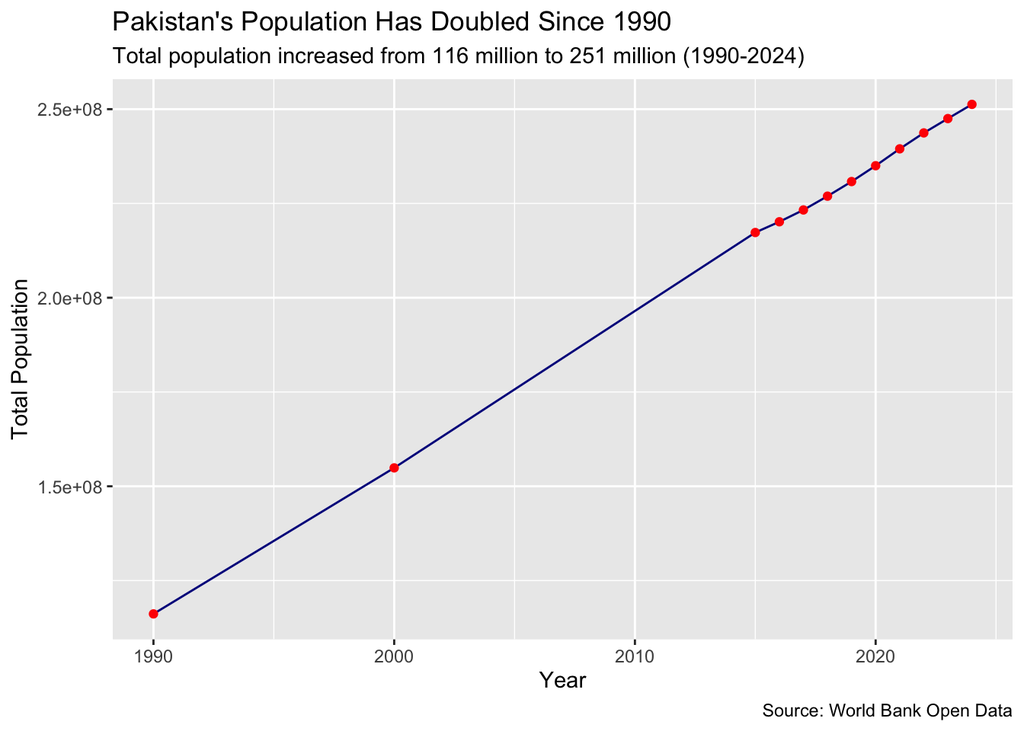

```r
# Filter for population data
population_data <- data_long |>
  filter(`Series Code` == "SP.POP.TOTL")

# Create the plot
ggplot(population_data, aes(x = year, y = value)) +
  geom_line(color = "darkblue") +
  geom_point(color = "red") +
  scale_y_continuous(
  ) +
  labs(
    title = "Pakistan's Population Has Doubled Since 1990",
    subtitle = "Total population increased from 116 million to 251 million (1990-2024)",
    x = "Year",
    y = "Total Population",
    caption = "Source: World Bank Open Data"
  )
```

```r
setwd("/Users/daija/Desktop/Academics/MIDP_24_26/MIDP_yr2/Data Science/a4stretch1/stretch")
dataset <- read_csv("dataset.csv")
data <- read.csv("dataset.csv")
unique(dataset$`Series Name`)
```

```
 [1] "Population, total"
 [2] "Population growth (annual %)"
 [3] "Surface area (sq. km)"
 [4] "Population density (people per sq. km of land area)"
 [5] "Poverty headcount ratio at national poverty lines (% of population)"
 [6] "Poverty headcount ratio at $3.00 a day (2021 PPP) (% of population)"
 [7] "GNI, Atlas method (current US$)"
 [8] "GNI per capita, Atlas method (current US$)"
 [9] "GNI, PPP (current international $)"
[10] "GNI per capita, PPP (current international $)"
[11] "Income share held by lowest 20%"
[12] "Life expectancy at birth, total (years)"
[13] "Fertility rate, total (births per woman)"
[14] "Adolescent fertility rate (births per 1,000 women ages 15-19)"
[15] "Contraceptive prevalence, any method (% of married women ages 15-49)"
```

[output cut: 46 more lines]